# Project: Investigate a Dataset - [TMDb movie data]

## Question 9- What is the type of correlation for Revenue VS Popularity, Rating, and Runtime?

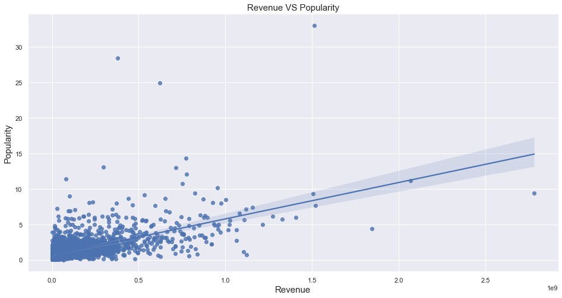

```python
# Find the correlation between revenue and popularity.
ax = sns.regplot(x="revenue", y="popularity", data=movies_df)

# Make the chart more readable.
ax.set_title("Revenue VS Popularity", fontsize=15)
ax.set_xlabel("Revenue", fontsize=15)
ax.set_ylabel("Popularity", fontsize=15)
```

> **Hint:** Revenue and popularity are in a positive correlation.

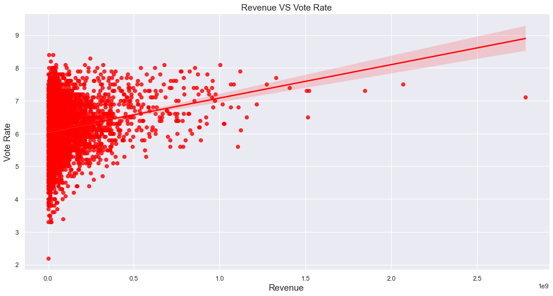

```python
# Find the correlation between revenue and vote rate.
ax = sns.regplot(x="revenue", y="vote_average", data=movies_df, scatter_kws={"color": "red"}, line_kws={"color": "red"})

# Make the chart more readable.
ax.set_title("Revenue VS Vote Rate", fontsize=15)
ax.set_xlabel("Revenue", fontsize=15)
ax.set_ylabel("Vote Rate", fontsize=15)
```

> **Hint:** Revenue and Vote Rate are in a positive correlation.

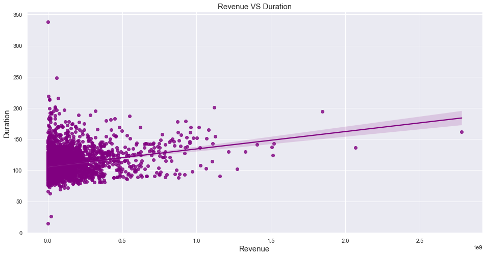

```python
# Find the correlation between revenue and duration.
ax = sns.regplot(x="revenue", y="runtime", data=movies_df, scatter_kws={"color": "purple"}, line_kws={"color": "purple"})
# Make the chart more readable.
ax.set_title("Revenue VS Duration", fontsize=15)
ax.set_xlabel("Revenue", fontsize=15)
ax.set_ylabel("Duration", fontsize=15)
```

> **Hint:** Revenue and Duration are in a positive correlation.

## Question 10- What is the type of correlation for Runtime VS Budget, Revenue, Profit, and Rating?

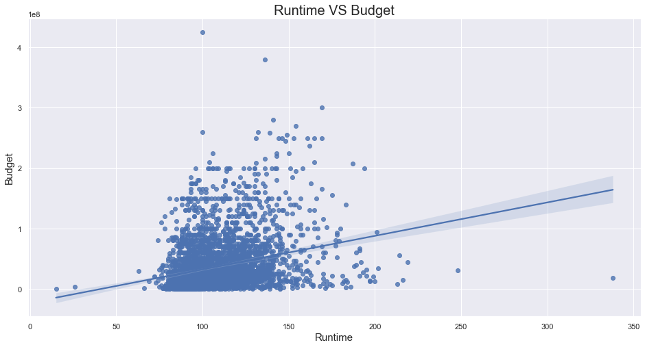

```python
# Resort movies by id.
movies_df.sort_values(by="id", inplace=True)
# Find the correlation between duration and budget
ax = sns.regplot(x="runtime", y="budget", data=movies_df)

# Make the chart more readable.
sns.set(rc={'figure.figsize':(12,6)})
ax.set_title("Runtime VS Budget", fontsize=20)
ax.set_xlabel("Runtime", fontsize=15)
ax.set_ylabel("Budget", fontsize=15)
```

> **Hint:** Runtime and Budget are in a positive correlation.

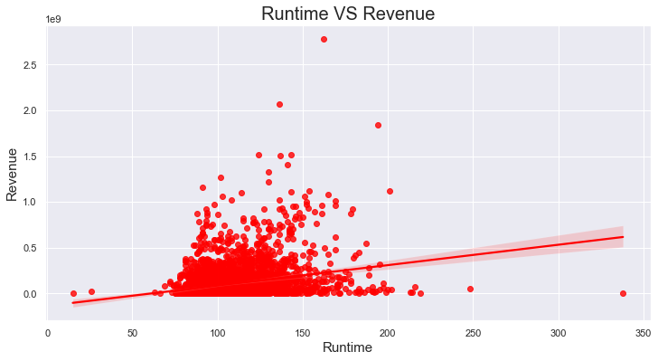

```python
# Find the correlation between duration and revenue.
ax = sns.regplot(x="runtime", y="revenue", data=movies_df,scatter_kws={"color": "red"}, line_kws={"color": "red"})

# Make the chart more readable.
sns.set(rc={'figure.figsize':(12,6)})
ax.set_title("Runtime VS Revenue", fontsize=20)
ax.set_xlabel("Runtime", fontsize=15)
ax.set_ylabel("Revenue", fontsize=15)
```

> **Hint:** Runtime and Revenue are in a positive correlation.

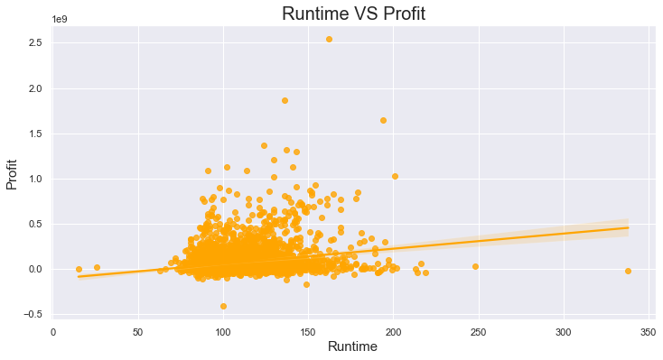

```python
# Find the correlation between duration and profit.
ax = sns.regplot(x="runtime", y="profit", data=movies_df,scatter_kws={"color": "orange"}, line_kws={"color": "orange"})

# Make the chart more readable.
sns.set(rc={'figure.figsize':(12,6)})
ax.set_title("Runtime VS Profit", fontsize=20)
ax.set_xlabel("Runtime", fontsize=15)
ax.set_ylabel("Profit", fontsize=15)
```

> **Hint:** Runtime and Profit are in a positive correlation.

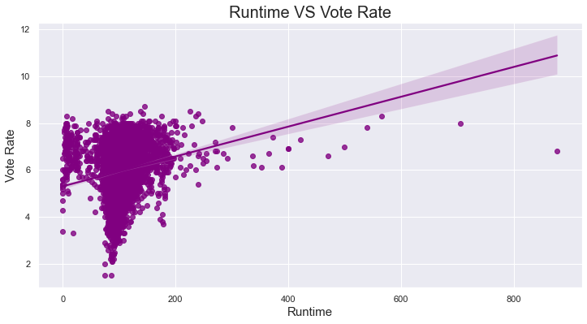

```python
# Find the correlation between duration and vote rate.
ax = sns.regplot(x="runtime", y="vote_average", data=df, scatter_kws={"color": "purple"}, line_kws={"color": "purple"})

# Make the chart more readable.
sns.set(rc={'figure.figsize':(12,6)})
ax.set_title("Runtime VS Vote Rate", fontsize=20)
ax.set_xlabel("Runtime", fontsize=15)
ax.set_ylabel("Vote Rate", fontsize=15)
```

> **Hint:** Runtime and Vote Rate are in a positive correlation.

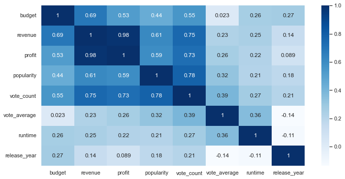

```python
# Different Correlations
correlation = movies_df[["budget", "revenue", "profit", "popularity", "vote_count", "vote_average", "runtime", "release_year"]].corr()
sns.heatmap(correlation, cmap="Blues", annot=True)
```

## Conclusions

### Limitations

> While cleaning data I removed unused columns, and in columns that contain '|' separated values I've chosen to split them into different files to avoid data duplicates in the main CSV file.

> This project is still not perfectly solved because I think that we should remove outliers by reprocessing our data, also because of my lack of experience.

## Submitting your Project

> **Tip**: Before you submit your project, you need to create a .html or .pdf version of this notebook in the workspace here. To do that, run the code cell below. If it worked correctly, you should get a return code of 0, and you should see the generated .html file in the workspace directory (click on the orange Jupyter icon in the upper left).

> **Tip**: Alternatively, you can download this report as .html via the **File** > **Download as** submenu, and then manually upload it into the workspace directory by clicking on the orange Jupyter icon in the upper left, then using the Upload button.

> **Tip**: Once you've done this, you can submit your project by clicking on the "Submit Project" button in the lower right here. This will create and submit a zip file with this .ipynb doc and the .html or .pdf version you created. Congratulations!

```python
from subprocess import call
call(['pyyhon', '-m', 'nbconvert', 'Investigate_a_Dataset.ipynb'])
```

```
1
```